# 15_sector_area

## 15_sector_area

#### Question

1. An arc is drawn along the circumference of a circle with a radius of $r=4$ meters. The arc’s length is $L=10.68$ meters. What is the corresponding [sector’s area](https://en.wikipedia.org/wiki/Circular_sector) (labelled $A$) in square meters?

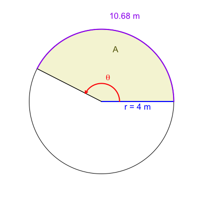

   Please give an exact answer (in $\mathrm{m^2}$).

#### Question

2. An arc is drawn along the circumference of a circle with a radius of $r=4$ meters. The arc’s length is $L=7.64$ meters. What is the corresponding [sector’s area](https://en.wikipedia.org/wiki/Circular_sector) (labelled $A$) in square meters?

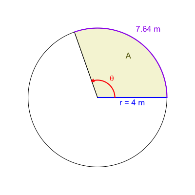

   Please give an exact answer (in $\mathrm{m^2}$).

#### Question

3. An arc is drawn along the circumference of a circle with a radius of $r=8$ meters. The arc’s length is $L=42$ meters. What is the corresponding [sector’s area](https://en.wikipedia.org/wiki/Circular_sector) (labelled $A$) in square meters?

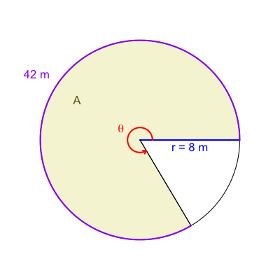

   Please give an exact answer (in $\mathrm{m^2}$).

#### Question

4. An arc is drawn along the circumference of a circle with a radius of $r=6$ meters. The arc’s length is $L=22.98$ meters. What is the corresponding [sector’s area](https://en.wikipedia.org/wiki/Circular_sector) (labelled $A$) in square meters?

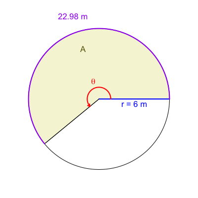

   Please give an exact answer (in $\mathrm{m^2}$).

#### Question

5. An arc is drawn along the circumference of a circle with a radius of $r=5$ meters. The arc’s length is $L=9.65$ meters. What is the corresponding [sector’s area](https://en.wikipedia.org/wiki/Circular_sector) (labelled $A$) in square meters?

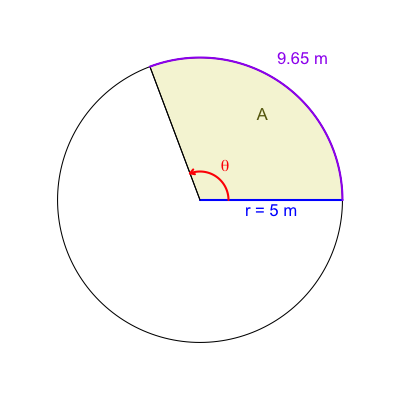

   Please give an exact answer (in $\mathrm{m^2}$).

#### Question

6. An arc is drawn along the circumference of a circle with a radius of $r=6$ meters. The arc’s length is $L=24.54$ meters. What is the corresponding [sector’s area](https://en.wikipedia.org/wiki/Circular_sector) (labelled $A$) in square meters?

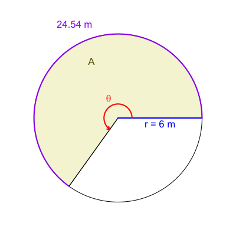

   Please give an exact answer (in $\mathrm{m^2}$).

#### Question

7. An arc is drawn along the circumference of a circle with a radius of $r=8$ meters. The arc’s length is $L=35.68$ meters. What is the corresponding [sector’s area](https://en.wikipedia.org/wiki/Circular_sector) (labelled $A$) in square meters?

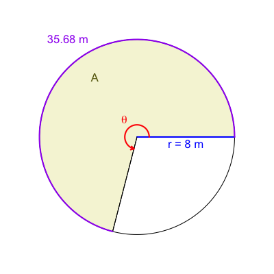

   Please give an exact answer (in $\mathrm{m^2}$).

#### Question

8. An arc is drawn along the circumference of a circle with a radius of $r=5$ meters. The arc’s length is $L=21.15$ meters. What is the corresponding [sector’s area](https://en.wikipedia.org/wiki/Circular_sector) (labelled $A$) in square meters?

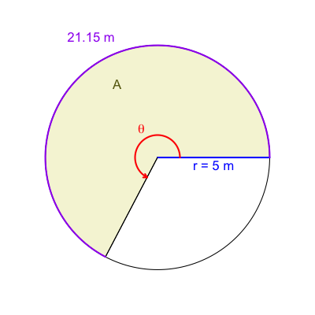

   Please give an exact answer (in $\mathrm{m^2}$).